# pump_sensors slides

1. The Task
2. The Data
3. Deviation-Indicator
4. ML-Approach

# The task

## Predictive Maintenance

- Using sensor data to predict the breakdowns of pumps.
- Allows for maintenance **before** a pump goes down.

## Benefits

- Cost benefits as regular maintenance-cycles can be reduced.
- No profits are lost due to outages
- Pumps usage period can be extended
- Happy customers stay and are willing to pay a higher premium over competitors.

# The Data

## What data

- Source: Kaggle competition
- 50 sensor data (No 15 is out of service, varying units of measurement)
- Machine status,
  - normal (205.836),
  - broken (7) and
  - recovering (14.477)

## Some Descriptives

- Time period: from 2018, April the first, midnight, to the end of August.
- Frequency of recording: Minutes.
- Number of observations: 220.320

## When Did the Pumps Break?

- Seasonality can not be considered due to sample
- Mostly during nighttime

|  | Breakdowns |
| --- | --- |
| 0 | 2018-04-12 21:55:00 |
| 1 | 2018-04-18 00:30:00 |
| 2 | 2018-05-19 03:18:00 |
| 3 | 2018-05-25 00:30:00 |
| 4 | 2018-06-28 22:00:00 |
| 5 | 2018-07-08 00:11:00 |
| 6 | 2018-07-25 14:00:00 |

## Some Interesting Sensors

### Percentage of Median: Broken vs. Normal

|  | 0 |
| --- | --- |
| sensor_00 | 16.159705 |
| sensor_29 | 15.159734 |
| sensor_38 | 12.455168 |
| sensor_04 | 10.016415 |
| sensor_42 | 7.885965 |

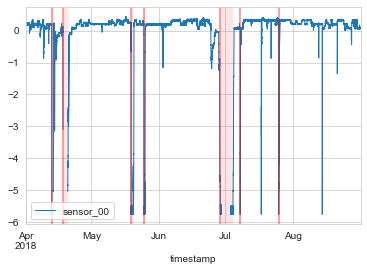

### Correlation of Sensors with Status

- Order by strength:

|  | machine_status |
| --- | --- |
| machine_status | 1.000000 |
| sensor_38 | 0.016723 |
| sensor_39 | 0.013102 |
| sensor_41 | 0.012187 |
| sensor_40 | 0.010135 |

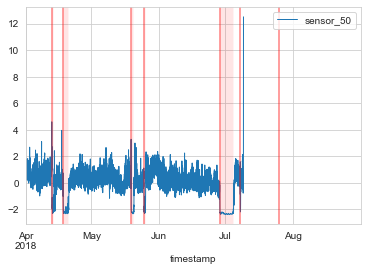

# Indicator Approach

- When did sensors deviate significantly (5 %-level) from normal state.
- How many sensors deviated
- Here: Mean of rolling window of 2 days.

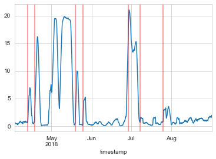

## Points to Consider

- Many False Alarms
- There seems to be a time trend (age of pumps)
- An objective rule (still) needs to be developed, when to go looking after pumps.

# ML Approach

## Predicting online

- is it possible to predict breakdowns online?

### Training

- Simple Logistic Regression, untuned
- split into 75 % Training (5 breakdowns), 25 % Test (2 breakdowns)

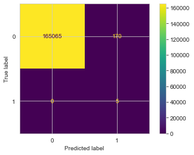

### Test (Unseen) Data

- one of 2 breakdowns can get predicted

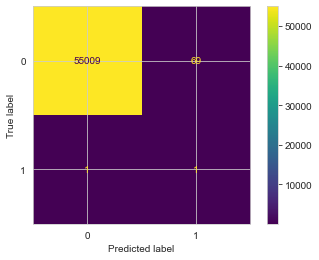

## Early Warning Indicator

- Give maintenance staff an early indicator of 2d.
- Point forecasts of breakdowns failed so far.
- Probabilities of breakdown, however, serve as early warning indicator.

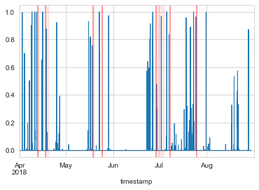

# Next Steps

- Use different ML-Models, including LSTM.
- Fine-tune models
- Use early-warning indicator and/or deviation-indicator in models.
- Use PCA to shrink number of regressors

**THANK YOU!**